# Case Study 1: National Collaborative Perinatal Project

1/20/2020

## EDA

## EDA: Missing Data

- Over 90% missing `albumin`, around 20% missing `score_*`, others less than 0.1%
- Drop the `albumin` and keep the complete cases

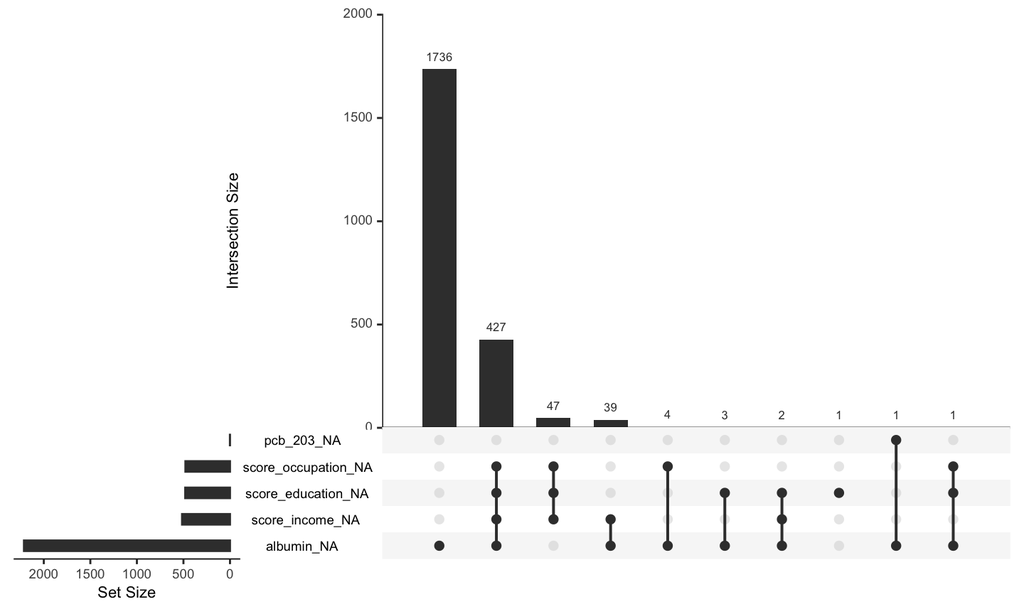

## EDA: Correlation Plot

- Weak correlation between covariates and `gestational age`
- Large correlation among covariates especially for PCBs

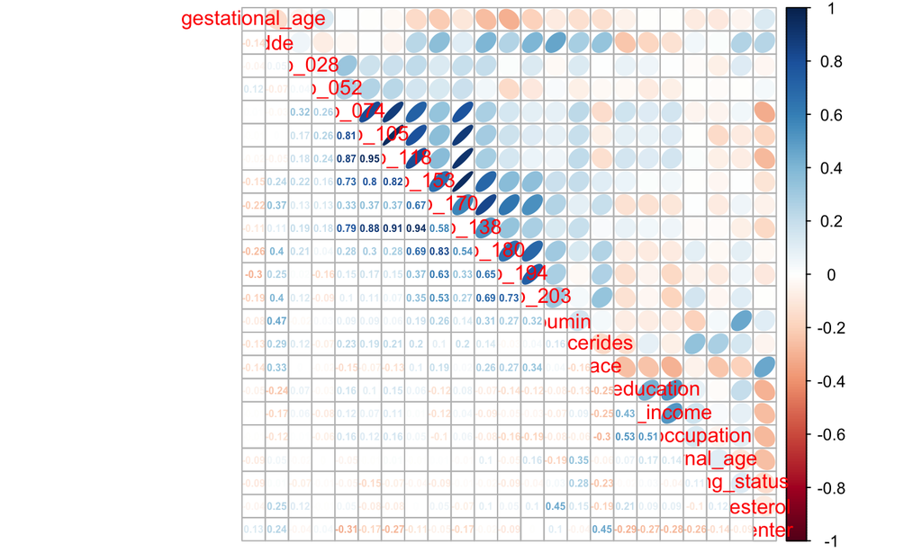

## EDA: Histogram for All Variables

- 0-inflation on some of PCBs
- Long left tail of `gestational age` (after truncated at 46)

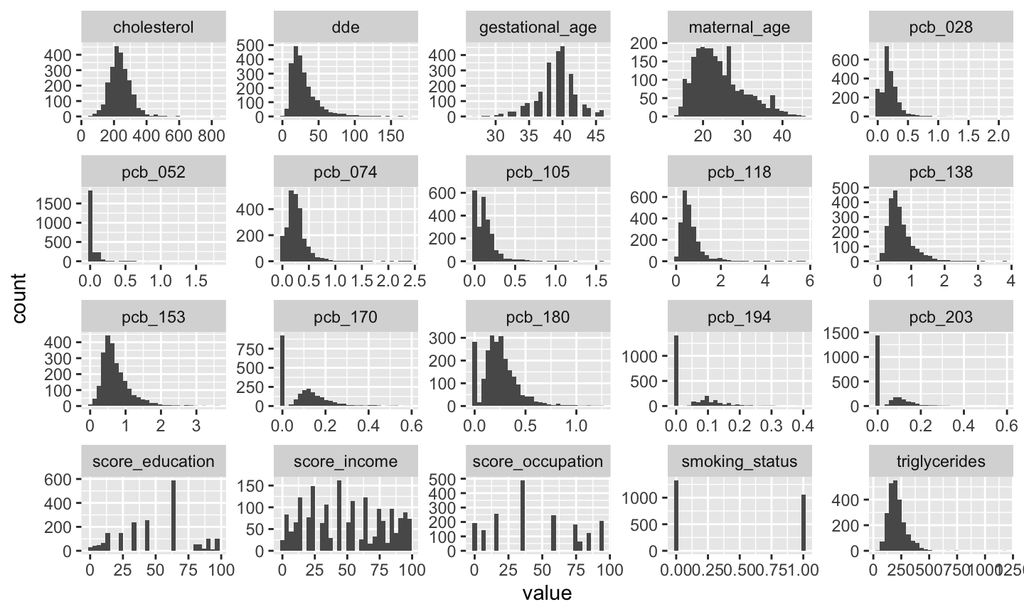

## EDA: Heterogeneity across Centers

The demographic background of each center varies a lot, suggesting heterogeity across centers. (favor fixed effect instead of random effect)

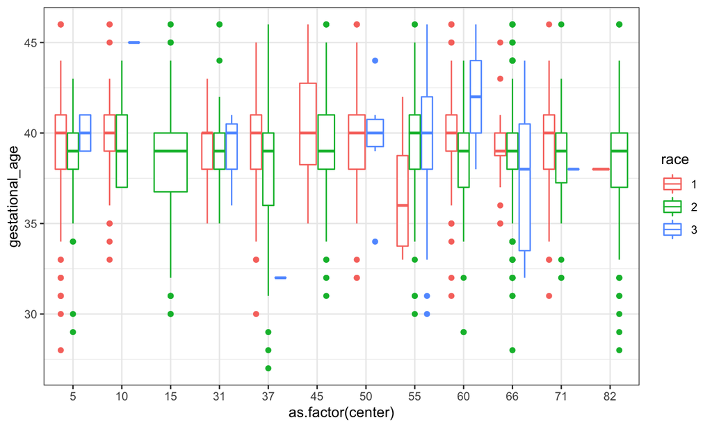

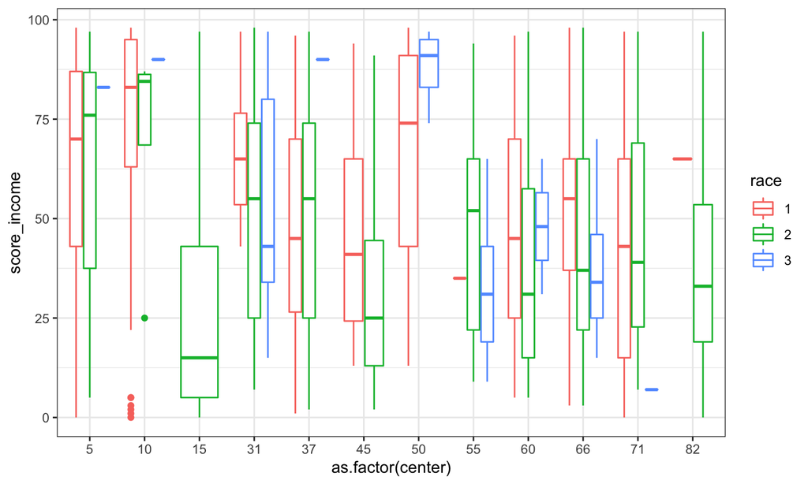

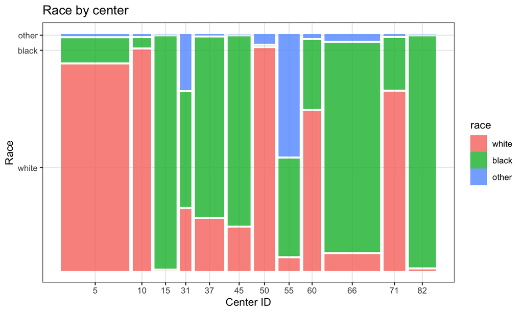

## Challenges

- Noisy measurement
- Multicollinearity
- Modeling Heterogeneity between centers

## Modeling

## Models

Goal: Assess how DDE and PCBs relate to risk of premature delivery

\[ \begin{aligned} \text{Null model:}\quad\text{gestational age} \sim 1 + \text{...} \\ \text{Alternative:}\quad\text{gestational age} \sim 1 + DDE + \text{...} \end{aligned} \] Consider a binary outcome with theshold at 37 and a continuous outcome.

## Regression estimates

95% confidence interval for Gaussian regression:

```
##       Mean  2.5 % 97.5 %
## dde -0.006 -0.013  0.002
## PC1  0.197  0.007  0.387
```

For logistic regression:

```
##       Mean  2.5 % 97.5 %
## dde  0.009  0.002  0.015
## PC1 -0.248 -0.435 -0.054
```

- Hard to see improvement from a “baseline” model (Gaussian)

## Diagnostic Plots

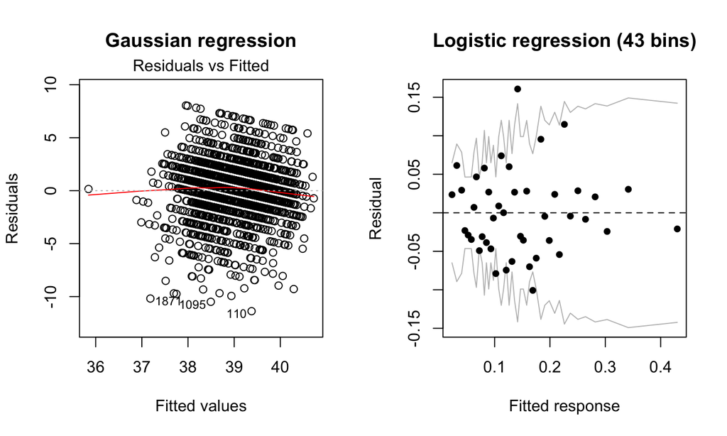

## Discussion

## Dealing with PCBs (multilinearity)

- Aggregating information of all the PCB’s (PCA -> hard to interpretate)
- Selecting representative PCB’s (Frequentist and Bayesian variable selection)
  - Bayesian Model Averaging
  - Horseshoe Prior
  - Hierarchical Prior
  - Lasso (Gaussian: dde, pcb_028, 074, 153; Logistic: dde, pcb_074, 153) -> ‘consistent’ with the previous model

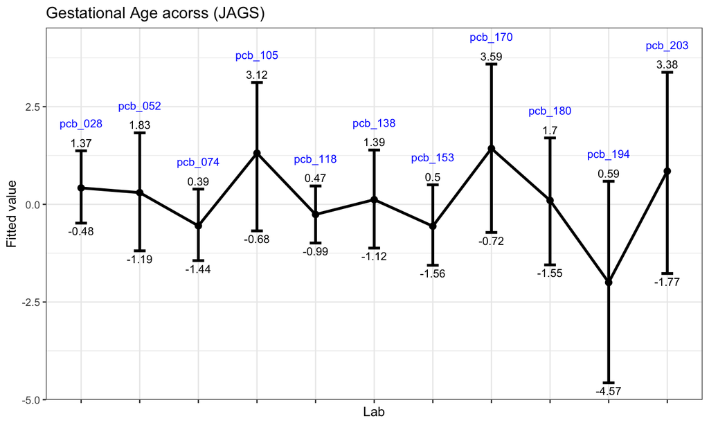

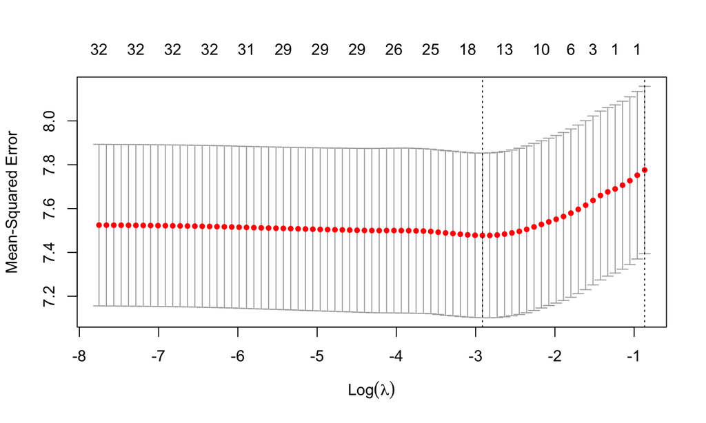

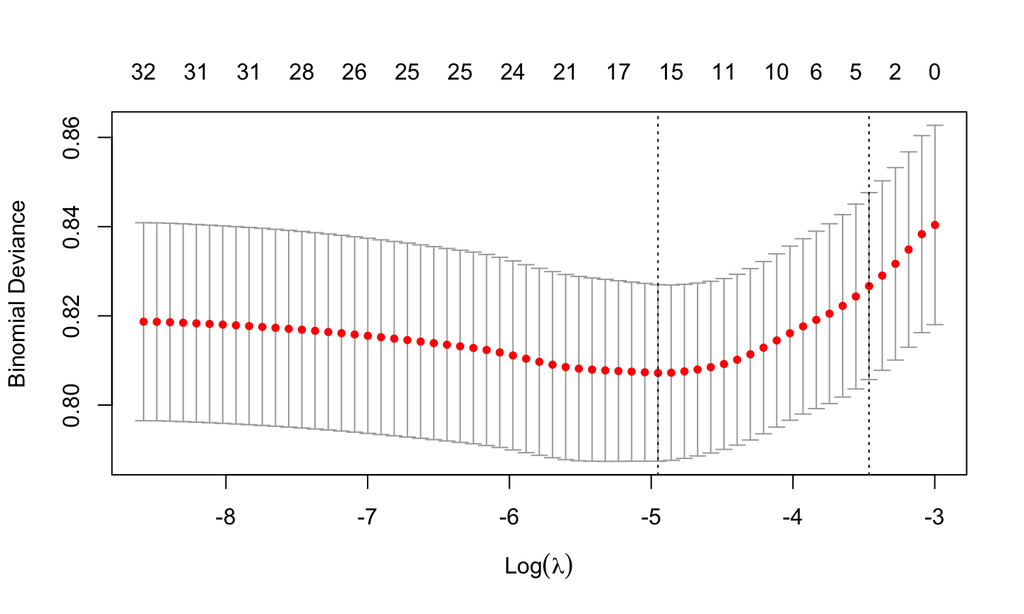

```
## 33 x 1 sparse Matrix of class "dgCMatrix"
##                            s0
## (Intercept)      40.177029263
## dde              -0.004075223
## pcb_028           0.012117044
## pcb_052           .
## pcb_074          -0.235776178
## pcb_105           .
## pcb_118           .
## pcb_153          -0.203115300
## pcb_170           .
## pcb_138           .
## pcb_180           .
## pcb_194           .
## pcb_203           .
## triglycerides    -0.002967824
## raceblack        -0.599605885
## raceother         .
## score_education   0.002135447
## score_income      0.001142959
## score_occupation  0.000236693
## maternal_age      .
## smoking_status   -0.006204116
## cholesterol       .
## center10          0.284185769
## center15         -0.265367329
## center31          0.008705241
## center37         -0.458489235
## center45          0.326979236
## center50          0.035527520
## center55          .
## center60          .
## center66          .
## center71          .
## center82         -0.325043522
```

```
## 33 x 1 sparse Matrix of class "dgCMatrix"
##                             s0
## (Intercept)      -2.3767513404
## dde               0.0082905083
## pcb_028           .
## pcb_052           .
## pcb_074           0.0857620096
## pcb_105           .
## pcb_118           .
## pcb_153           0.2404109151
## pcb_170           .
## pcb_138           .
## pcb_180           .
## pcb_194           .
## pcb_203           .
## triglycerides     0.0017302152
## raceblack         0.3297530277
## raceother         0.0205384728
## score_education  -0.0029318265
## score_income     -0.0017525832
## score_occupation -0.0030370731
## maternal_age      .
## smoking_status    0.0417963722
## cholesterol      -0.0006547262
## center10         -0.3906824063
## center15          0.3362855800
## center31         -0.3562138026
## center37          0.5215473887
## center45          .
## center50          .
## center55          .
## center60          .
## center66          .
## center71          .
## center82          0.1214926990
```

```
## Analysis of Variance Table
##
## Model 1: y ~ (dde + pcb_028 + pcb_052 + pcb_074 + pcb_105 + pcb_118 +
##     pcb_153 + pcb_170 + pcb_138 + pcb_180 + pcb_194 + pcb_203 +
##     triglycerides + race + score_education + score_income + score_occupation +
##     maternal_age + smoking_status + cholesterol + center) - dde -
##     pcb_028 - pcb_052 - pcb_074 - pcb_105 - pcb_118 - pcb_153 -
##     pcb_170 - pcb_138 - pcb_180 - pcb_194 - pcb_203
## Model 2: y ~ (dde + pcb_028 + pcb_052 + pcb_074 + pcb_105 + pcb_118 +
##     pcb_153 + pcb_170 + pcb_138 + pcb_180 + pcb_194 + pcb_203 +
##     triglycerides + race + score_education + score_income + score_occupation +
##     maternal_age + smoking_status + cholesterol + center) - pcb_028 -
##     pcb_052 - pcb_074 - pcb_105 - pcb_118 - pcb_153 - pcb_170 -
##     pcb_138 - pcb_180 - pcb_194 - pcb_203
##   Res.Df   RSS Df Sum of Sq      F  Pr(>F)
## 1   1834 13608
## 2   1833 13574  1     33.95 4.5846 0.03239 *
## ---
## Signif. codes:  0 '***' 0.001 '**' 0.01 '*' 0.05 '.' 0.1 ' ' 1
```

```
## Analysis of Variance Table
##
## Model 1: y ~ (dde + pcb_028 + pcb_052 + pcb_074 + pcb_105 + pcb_118 +
##     pcb_153 + pcb_170 + pcb_138 + pcb_180 + pcb_194 + pcb_203 +
##     triglycerides + race + score_education + score_income + score_occupation +
##     maternal_age + smoking_status + cholesterol + center) - dde -
##     pcb_028 - pcb_052 - pcb_074 - pcb_105 - pcb_118 - pcb_153 -
##     pcb_170 - pcb_138 - pcb_180 - pcb_194 - pcb_203
## Model 2: y ~ (dde + pcb_028 + pcb_052 + pcb_074 + pcb_105 + pcb_118 +
##     pcb_153 + pcb_170 + pcb_138 + pcb_180 + pcb_194 + pcb_203 +
##     triglycerides + race + score_education + score_income + score_occupation +
##     maternal_age + smoking_status + cholesterol + center) - dde -
##     pcb_052 - pcb_105 - pcb_118 - pcb_170 - pcb_138 - pcb_180 -
##     pcb_194 - pcb_203
##   Res.Df   RSS Df Sum of Sq      F  Pr(>F)
## 1   1834 13608
## 2   1831 13530  3    77.102 3.4779 0.01541 *
## ---
## Signif. codes:  0 '***' 0.001 '**' 0.01 '*' 0.05 '.' 0.1 ' ' 1
```

```
## Analysis of Deviance Table
##
## Model 1: y ~ (dde + pcb_028 + pcb_052 + pcb_074 + pcb_105 + pcb_118 +
##     pcb_153 + pcb_170 + pcb_138 + pcb_180 + pcb_194 + pcb_203 +
##     triglycerides + race + score_education + score_income + score_occupation +
##     maternal_age + smoking_status + cholesterol + center) - dde -
##     pcb_028 - pcb_052 - pcb_074 - pcb_105 - pcb_118 - pcb_153 -
##     pcb_170 - pcb_138 - pcb_180 - pcb_194 - pcb_203
## Model 2: y ~ (dde + pcb_028 + pcb_052 + pcb_074 + pcb_105 + pcb_118 +
##     pcb_153 + pcb_170 + pcb_138 + pcb_180 + pcb_194 + pcb_203 +
##     triglycerides + race + score_education + score_income + score_occupation +
##     maternal_age + smoking_status + cholesterol + center) - pcb_028 -
##     pcb_052 - pcb_074 - pcb_105 - pcb_118 - pcb_153 - pcb_170 -
##     pcb_138 - pcb_180 - pcb_194 - pcb_203
##   Resid. Df Resid. Dev Df Deviance
## 1      1834     1464.8
## 2      1833     1452.9  1   11.956
```

```
## Analysis of Deviance Table
##
## Model 1: y ~ (dde + pcb_028 + pcb_052 + pcb_074 + pcb_105 + pcb_118 +
##     pcb_153 + pcb_170 + pcb_138 + pcb_180 + pcb_194 + pcb_203 +
##     triglycerides + race + score_education + score_income + score_occupation +
##     maternal_age + smoking_status + cholesterol + center) - dde -
##     pcb_028 - pcb_052 - pcb_074 - pcb_105 - pcb_118 - pcb_153 -
##     pcb_170 - pcb_138 - pcb_180 - pcb_194 - pcb_203
## Model 2: y ~ (dde + pcb_028 + pcb_052 + pcb_074 + pcb_105 + pcb_118 +
##     pcb_153 + pcb_170 + pcb_138 + pcb_180 + pcb_194 + pcb_203 +
##     triglycerides + race + score_education + score_income + score_occupation +
##     maternal_age + smoking_status + cholesterol + center) - dde -
##     pcb_052 - pcb_105 - pcb_118 - pcb_170 - pcb_138 - pcb_180 -
##     pcb_194 - pcb_203
##   Resid. Df Resid. Dev Df Deviance
## 1      1834     1464.8
## 2      1831     1449.1  3   15.753
```

```
##
## Call:
## lm(formula = y ~ . - pcb_028 - pcb_052 - pcb_074 - pcb_105 -
##     pcb_118 - pcb_153 - pcb_170 - pcb_138 - pcb_180 - pcb_194 -
##     pcb_203, data = data_46_wscore)
##
## Residuals:
##      Min       1Q   Median       3Q      Max
## -11.3153  -1.2871   0.1745   1.5840   8.0453
##
## Coefficients:
##                    Estimate Std. Error t value Pr(>|t|)
## (Intercept)      40.0035707  0.4768109  83.898  < 2e-16 ***
## dde              -0.0075564  0.0035291  -2.141  0.03239 *
## triglycerides    -0.0039508  0.0008890  -4.444 9.36e-06 ***
## raceblack        -0.9370502  0.2285483  -4.100 4.31e-05 ***
## raceother        -0.6057361  0.4514277  -1.342  0.17982
## score_education   0.0029689  0.0029445   1.008  0.31345
## score_income      0.0023640  0.0025985   0.910  0.36307
## score_occupation  0.0004620  0.0026621   0.174  0.86224
## maternal_age     -0.0002268  0.0105987  -0.021  0.98293
## smoking_status   -0.1031512  0.1317824  -0.783  0.43388
## cholesterol       0.0001302  0.0010645   0.122  0.90264
## center10          0.5663335  0.2884601   1.963  0.04976 *
## center15          0.1600191  0.3571608   0.448  0.65418
## center31          0.8243645  0.4043490   2.039  0.04162 *
## center37         -0.2107640  0.2970692  -0.709  0.47812
## center45          0.9751249  0.3320170   2.937  0.00336 **
## center50          0.4289290  0.2805764   1.529  0.12650
## center55          1.0894006  0.5323170   2.047  0.04085 *
## center60          0.4828203  0.3177508   1.519  0.12881
## center66          0.5812285  0.2884075   2.015  0.04402 *
## center71          0.2549296  0.2980442   0.855  0.39247
## center82          0.0871577  0.3476726   0.251  0.80208
## ---
## Signif. codes:  0 '***' 0.001 '**' 0.01 '*' 0.05 '.' 0.1 ' ' 1
##
## Residual standard error: 2.721 on 1833 degrees of freedom
## Multiple R-squared:  0.0574, Adjusted R-squared:  0.0466
## F-statistic: 5.315 on 21 and 1833 DF,  p-value: 7.392e-14
```

```
##
## Call:
## lm(formula = y ~ . - dde - pcb_052 - pcb_105 - pcb_118 - pcb_170 -
##     pcb_138 - pcb_180 - pcb_194 - pcb_203, data = data_46_wscore)
##
## Residuals:
##      Min       1Q   Median       3Q      Max
## -11.3270  -1.3438   0.1428   1.6019   8.1749
##
## Coefficients:
##                    Estimate Std. Error t value Pr(>|t|)
## (Intercept)      40.0472233  0.4774892  83.870  < 2e-16 ***
## pcb_028           0.6826810  0.5180007   1.318  0.18770
## pcb_074          -0.5225221  0.4006148  -1.304  0.19230
## pcb_153          -0.3814200  0.2129693  -1.791  0.07346 .
## triglycerides    -0.0039954  0.0008915  -4.482 7.86e-06 ***
## raceblack        -0.9442079  0.2298255  -4.108 4.16e-05 ***
## raceother        -0.6556707  0.4506041  -1.455  0.14582
## score_education   0.0031892  0.0029444   1.083  0.27888
## score_income      0.0020980  0.0025959   0.808  0.41909
## score_occupation  0.0008498  0.0026649   0.319  0.74984
## maternal_age      0.0029854  0.0106970   0.279  0.78021
## smoking_status   -0.0909725  0.1324899  -0.687  0.49240
## cholesterol       0.0001721  0.0010760   0.160  0.87294
## center10          0.5727531  0.2900520   1.975  0.04846 *
## center15         -0.0784029  0.3659055  -0.214  0.83036
## center31          0.7218030  0.4069301   1.774  0.07627 .
## center37         -0.1869081  0.2991472  -0.625  0.53218
## center45          0.9266790  0.3330499   2.782  0.00545 **
## center50          0.2795031  0.2855448   0.979  0.32779
## center55          0.9233901  0.5348345   1.726  0.08443 .
## center60          0.2895631  0.3237984   0.894  0.37130
## center66          0.5456862  0.2899948   1.882  0.06003 .
## center71          0.2115565  0.3011306   0.703  0.48243
## center82         -0.1922020  0.3497272  -0.550  0.58268
## ---
## Signif. codes:  0 '***' 0.001 '**' 0.01 '*' 0.05 '.' 0.1 ' ' 1
##
## Residual standard error: 2.718 on 1831 degrees of freedom
## Multiple R-squared:  0.0604, Adjusted R-squared:  0.0486
## F-statistic: 5.117 on 23 and 1831 DF,  p-value: 3.67e-14
```

```
##
## Call:
## glm(formula = y ~ . - pcb_028 - pcb_052 - pcb_074 - pcb_105 -
##     pcb_118 - pcb_153 - pcb_170 - pcb_138 - pcb_180 - pcb_194 -
##     pcb_203, family = "binomial", data = data_46_wscore37)
##
## Deviance Residuals:
##     Min       1Q   Median       3Q      Max
## -1.2611  -0.6103  -0.4770  -0.3321   2.7476
##
## Coefficients:
##                    Estimate Std. Error z value Pr(>|z|)
## (Intercept)      -2.3791134  0.5143330  -4.626 3.73e-06 ***
## dde               0.0111504  0.0031594   3.529 0.000417 ***
## triglycerides     0.0030843  0.0008678   3.554 0.000379 ***
## raceblack         0.4770255  0.2471125   1.930 0.053558 .
## raceother         0.7768268  0.4927935   1.576 0.114940
## score_education  -0.0035881  0.0031153  -1.152 0.249414
## score_income     -0.0022077  0.0027833  -0.793 0.427662
## score_occupation -0.0029282  0.0028206  -1.038 0.299205
## maternal_age     -0.0046826  0.0111094  -0.422 0.673390
## smoking_status    0.1683631  0.1398744   1.204 0.228716
## cholesterol      -0.0013373  0.0011232  -1.191 0.233811
## center10         -0.7921340  0.4934280  -1.605 0.108413
## center15          0.3546565  0.3589019   0.988 0.323069
## center31         -1.1172358  0.5960807  -1.874 0.060889 .
## center37          0.6505293  0.3014629   2.158 0.030935 *
## center45         -0.0217392  0.3545285  -0.061 0.951105
## center50         -0.1164139  0.3688143  -0.316 0.752273
## center55         -0.5118940  0.5908276  -0.866 0.386270
## center60          0.0515059  0.3599369   0.143 0.886214
## center66         -0.0364439  0.3133063  -0.116 0.907399
## center71         -0.1975140  0.3634640  -0.543 0.586840
## center82          0.1646462  0.3576564   0.460 0.645267
## ---
## Signif. codes:  0 '***' 0.001 '**' 0.01 '*' 0.05 '.' 0.1 ' ' 1
##
## (Dispersion parameter for binomial family taken to be 1)
##
##     Null deviance: 1556.9  on 1854  degrees of freedom
## Residual deviance: 1452.9  on 1833  degrees of freedom
## AIC: 1496.9
##
## Number of Fisher Scoring iterations: 5
```

[output not shown]